# Essential Regression Vignette

### Housekeeping

Before beginning, please ensure that the following packages are installed and libraries are loaded. The Essential Regression package is available for downloading using the following code: `devtools::install_github("Hanxi-002/EssReg", auth_token = "TOKEN_HERE")` The other packages can be installed from CRAN.

```r
library(matrixcalc)
library(readr)
library(ROCR)
library(e1071)
library(dplyr)
library(doParallel)
library(foreach)
library(scales)
library(doRNG)
library(matlib)
library(BAS)
library(gmp)
library(EssReg)
```

We also recommend running some of these function in parallel. We prepare the environment for this using the following code:

```r
cores <- detectCores()
registerDoParallel(cores)
```

### Data Set-Up

We first must load in our data. Essential Regression accepts a data matrix ($\mathbf{X}$) of dimensions $n \times p$, where $n$ is the number of samples/patients/instances and $p$ is the number of features/variables, and a response vector ($\mathbf{Y}$) of dimension $n$ that can be either categorical or continuous.

This implementation of Essential Regression and its related functions all assume properly formatted and processed data. This data should be raw (non-standardized, non-normalized) as Essential Regression performs the standardization steps itself. However, this data should be pre-processed and cleaned. Missing values should be dealt with in an appropriate fashion (i.e. imputation, removal, etc.). Additionally, the structure and sparsity of $\mathbf{X}$ should be explored to ensure that the column-wise standard deviations do not equal zero and that there are no majority zero columns or rows.

If using the pipeline, the data should be provided as `.csv` files (alternative file formats coming soon). Column names are encouraged, and row names are optional. However, it is important that the column and row names are, in fact, column and row names rather than an extra column or row in the matrices themselves. If your data has row names as column #1 or column names as row #1, please remove them.

Finally, `plainER()` takes solely numerical data. If your response is categorical or ordinal, please take the time to transform it into a continuous variable. The `EssReg` package provides the `toCont()` function to assist in the transformation. `toCont()` has two arguments, `y` (the categorical response vector) and `order` (an optional argument that provides the levels of `y` in vector form). As an example, if you had injury severity as a response, then you could supply to `order` the vector `c("Mild", "Moderate", "Severe")`. The function will return a list including the categorical and continuous versions of `y` as well as the mapping performed.

As an example, we use a dataset of expression measurements of 892 genes from 24 patients. $\mathbf{Y}$ is the Modified Rodnan Skin Score. This dataset is included in the package:

```r
dim(EssReg::x_data); dim(EssReg::y_data)
```

```
## [1]  24 892
```

```
## [1] 24  1
```

For running the pipeline, the data can be found in `.csv` format in the `data/` folder.

### Running Essential Regression

The function, `plainER()`, requires non-standardized data because of an internal cross-validation regime. Thus, there is little pre-processing to perform before we can dive into using the package!

#### Running `plainER()`

Now that we understand the function specification, we can run Essential Regression.

```r
initial_run <- plainER(y = y_data,
                       x = x_data,
                       sigma = cor(x_data),
                       thresh_fdr = 0.2,
                       delta = seq(0.001, 0.1, 0.001),
                       lambda = 0.5,
                       alpha_level = 0.05,
                       rep_cv = 50,
                       out_path = "temp/")
```

`plainER()` has a significant amount of output, which we cover below.

If `out_path` is supplied to the call to `plainER()`, then the function also saves heatmaps of $\hat{\Sigma}$ and the thresholded version of $\hat{\Sigma}$.

#### Inspection of Results

We can peek at what $\delta$ `plainER()` decided to use after 50 replicates of cross-validation:

```r
initial_run$opt_delta
```

```
## [1] 0.039
```

#### Thresholded $\hat{\Sigma}$

We can also use the `makeHeatmap()` function, a wrapper for the `pheatmap()` function from `pheatmap`, to view the thresholded $\hat{\Sigma}$ matrix:

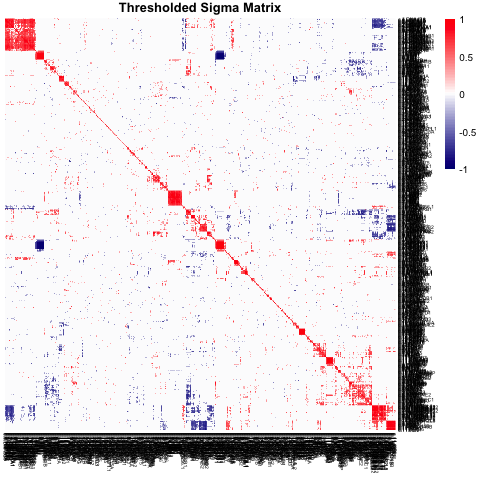

```r
makeHeatmap(mat = initial_run$thresh_sigma, ## matrix
            title = "Thresholded Sigma Matrix",  ## plot title
            cluster = T, ## boolean for clustering
            names = T) ## boolean for displaying column/row names
```

This should match with the heatmap created and saved within `plainER()`.

Note: The heatmaps will be saved to a directory labeled with either the value of $\delta$ used in Essential Regression if a single value is provided or the first value of $\delta$ in the range to search over if a sequence is provided.

#### Clusters

For more information on the clustering of the variables, we can use the `readER()` function. `readER()` takes as input the results of `plainER()` and the `x` matrix and returns a list of latent clusters, a vector fo pure variable indices, and a vector of mixed variable indices.

```r
initial_read <- readER(x, initial_run)
```

First 10 pure variables: c.0.KRT14, c.0.KRT5, c.0.KRT6B, c.0.KRT6C, c.0.LOR, c.0.FLG, c.0.LCE1C, c.0.FLG2, c.0.LCE2B, c.0.LCE1B

First 10 mixed variables: c.0.HES1, c.0.CST6, c.0.TCHH, c.0.KRT17, c.0.AREG, c.0.LYPD3, c.1.HES1, c.1.KRT17, c.1.APOE, c.1.FGFBP1

### Pipeline

#### Cross-Validation

We also provide a cross-validation regime based upon `K-CV()` in the original Essential Regression package. This regime is implemented in the function `essregCV()`, which accepts all of the parameters used in `plainER()` and `priorER()` in addition to a few others. (you should never need to run `essregCV()` because it is called within the pipeline, but it is important to understand what its arguments are):

- `k`: The number of folds to use for training/validation set creation.
- `eval_type`: A string indicating the type of evaluation metric to use for the method comparison. Can be “corr” or “auc”. REQUIRED
- `y_factor`: A boolean flag indicating whether `y` is categorical (`TRUE`) or continuous (`FALSE`).
- `y_levels`: A vector of values indicating the order of levels in ordinal `y`.
- `permute`: A boolean flag indicating whether to permute the response as a baseline comparison. Only LASSO and plainER will be performed with the permuted responses. REQUIRED
- `rep`: The replicate number. This is only used for saving intermediate output during cross-validation.

#### Pipeline Steps

The main contribution of this package is a pipeline for the estimation of the hyperparameters of Essential Regression, $\delta$ and $\lambda$. The pipeline consists of four steps, which are split into two functions: `pipelineER1()` and `pipelineER2()`. The algorithm is as follows:

**`pipeline1()`**

Step 2:

- Run `essregCV()` for $r$ replicates
- Plot the model performance for user inspection
  - This step creates a boxplot of the average MSE/AUC/Spearman correlations by $\delta$. Separate boxes for no permutations and $y$ permutations are created if permutations of $y$ are conducted.

`pipeline1()` also supports the specification of steps to run using the parameter `steps`. This parameter can be set to `1`, `2`, or `all`. For the sake of this example, we run all steps.

**`pipeline2()`**

The second half of the Essential Regression pipeline requires the user to specify a range over which to conduct a fine search for $\delta$. Alternatively, the user can supply a single value, and the function will create its own fine grid around the provided value.

Step 3:

- Run `plainER()` on the provided (or generated) fine $\delta$ grid.

Step 4:

- For each value of $\lambda$ in the vector provided by the user:
  - Run `essregCV()` for $r$ replicates.
- Plot the model performance for user inspection.
  - This step creates a boxplot of the average MSE/AUC/Spearman correlations by $\lambda$. Separate boxes for no permutations and $y$ permutations are created if permutations of $y$ are conducted.

After running both `pipelineER1()` and `pipelineER2()`, a user will have boxplots that provide insight into the optimal values to use for $\delta$ and $\lambda$.

#### Running `pipelineER1()`

Both pipeline functions require `steps` and a path to a .yaml file (`yaml_path`) that contains all of the other parameter values. We organize the functions in this way to facilitate scripting.

Below is an example .yaml file for `pipelineER1()` to show the correct formatting:

```r
---
x_path: /path/to/x_data   # path to .csv file for data matrix
y_path: /path/to/y_data   # path to .csv file for response vector
out_path: /output/path/   # path to directory for saving results
k: 5                      # number of folds for cross-validation
y_factor: F               # is y a categorical variable?
y_levels: NULL             # if y is ordinal, provide the levels (Ex: ["Mild", "Moderate", "Severe"])
eval_type: "corr"         # evaluation metric for method comparison
permute: TRUE             # permute y during comparison?
rep_cv: 50                # number of replicates for cross-validation for delta
nreps: 10                 # number of replicates for cross-validation in step 2
alpha_level: 0.05         # alpha level for confidence intervals
thresh_fdr: 0.2           # false discovery rate thresholding p-value cutoff
```

```r
pipe1_run <- pipelineER1(yaml_path = "~/pipeline1.yaml", steps = "all")
```

#### Running `pipelineER2()`

From the output of steps 1 and 2, we choose a value around which to center our fine $\delta$ search. For this example, we chose 0.03. We also provide a grid over which to perform a search for the optimal value of $\lambda$. Below is an example .yaml file for `pipelineER2()` to show the correct formatting:

```r
---
x_path: /path/to/x_data    # path to .csv file for data matrix
y_path: /path/to/y_data    # path to .csv file for response vector
out_path: /output/path/    # path to directory for saving results
k: 5                       # number of folds for cross-validation
delta: 0.03                # chosen delta (or delta grid for fine search)
lambda: [0.1, 0.5, 1, 1.5] # lambda grid
y_factor: FALSE            # is y categorical?
y_levels: NULL              # if y is ordinal, provide the levels (Ex: ["Mild", "Moderate", "Severe"])
rep_cv: 50                 # number of replicates for cross-validation for delta
nreps: 10                  # number of replicates for cross-validation in step 4
eval_type: "corr"          # evaluation metric for method comparison
permute: TRUE              # permute y during comparison?
alpha_level: 0.05          # alpha level for confidence intervals
thresh_fdr: 0.2            # false discovery rate thresholding p-value cutoff
```

```r
pipe2_run <- pipelineER2(yaml_path = "~/pipeline2.yaml", steps = "all")
```

### Pipeline Plots

#### `pipelineER1()` Plots

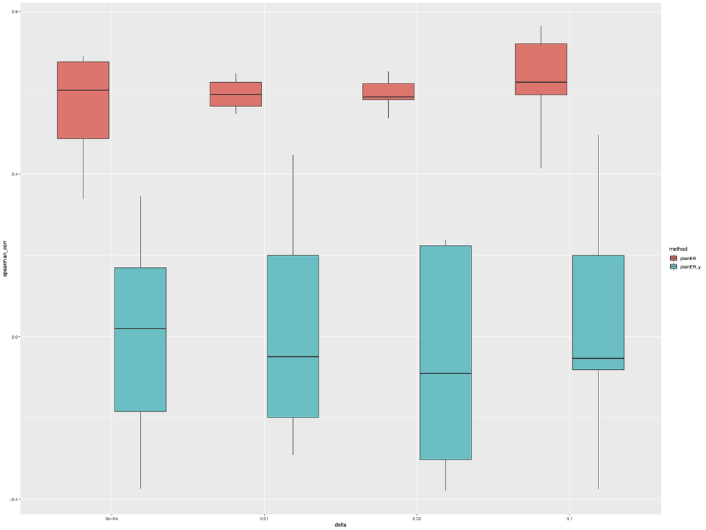

Delta Selection Boxplot

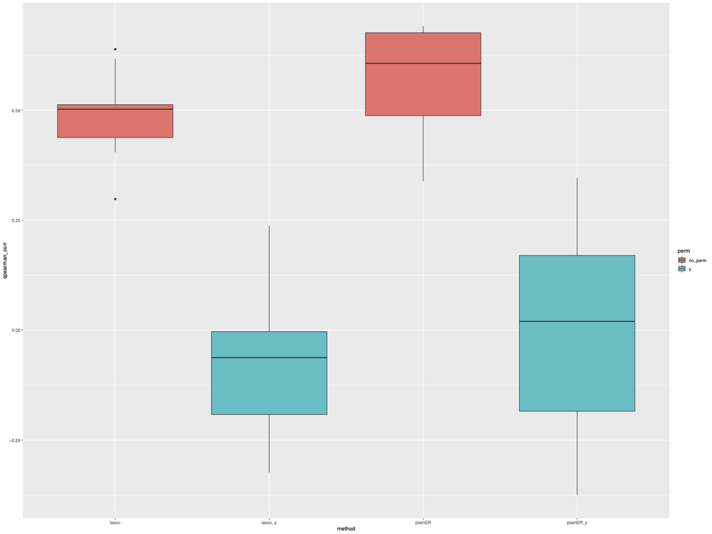

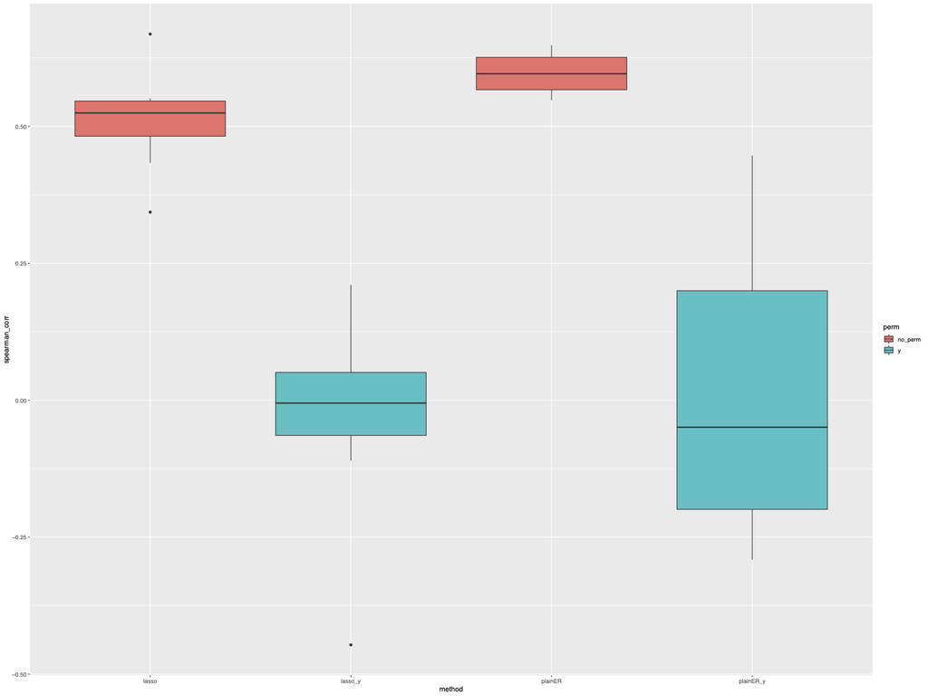

Delta = 9e-04 & 0.01 Boxplots

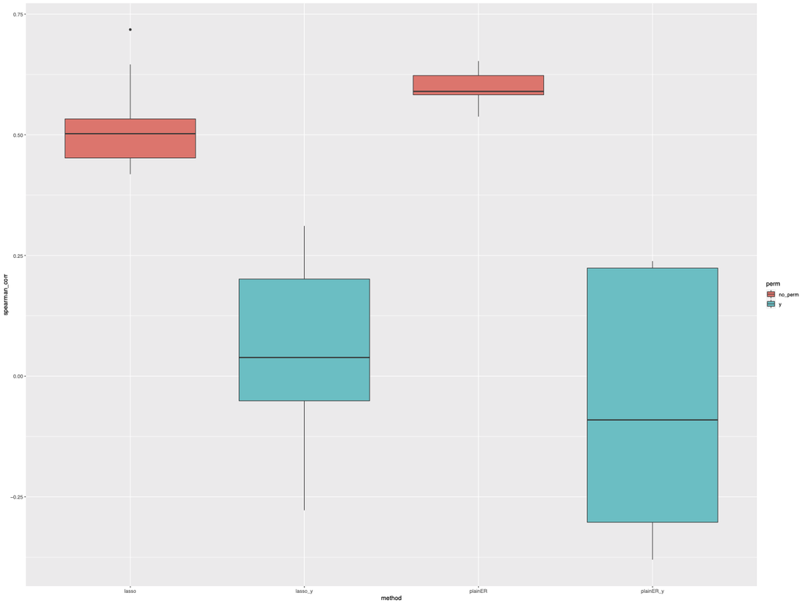

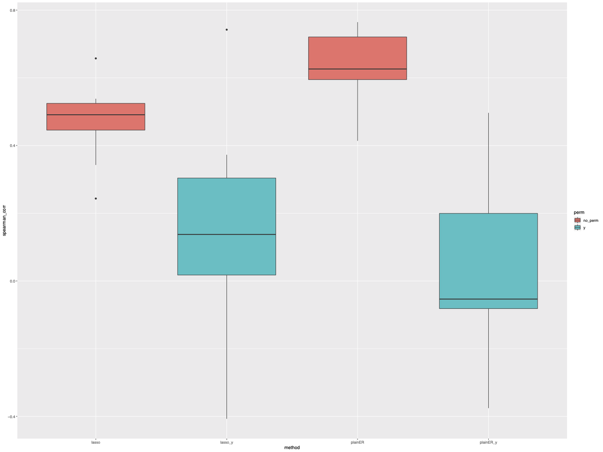

Delta = 0.02 & 0.1 Boxplots

#### `pipelineER2()` Plots

[figure not shown]

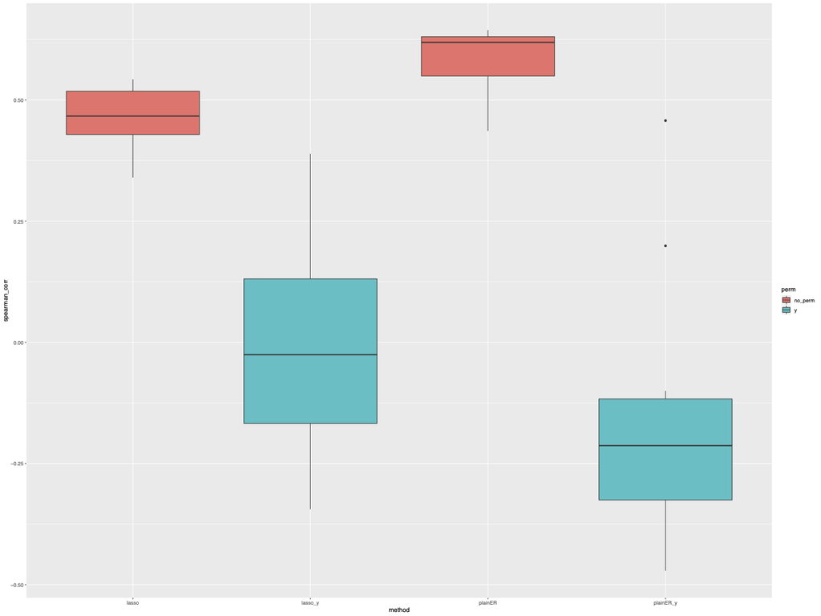

Lambda Selection and Lambda = 0.5 Boxplots

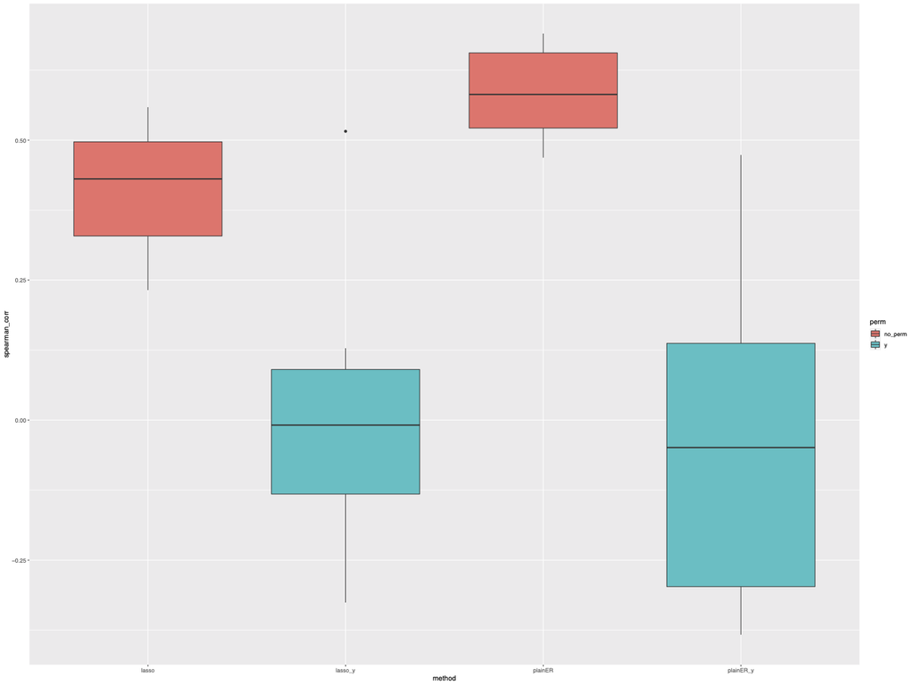

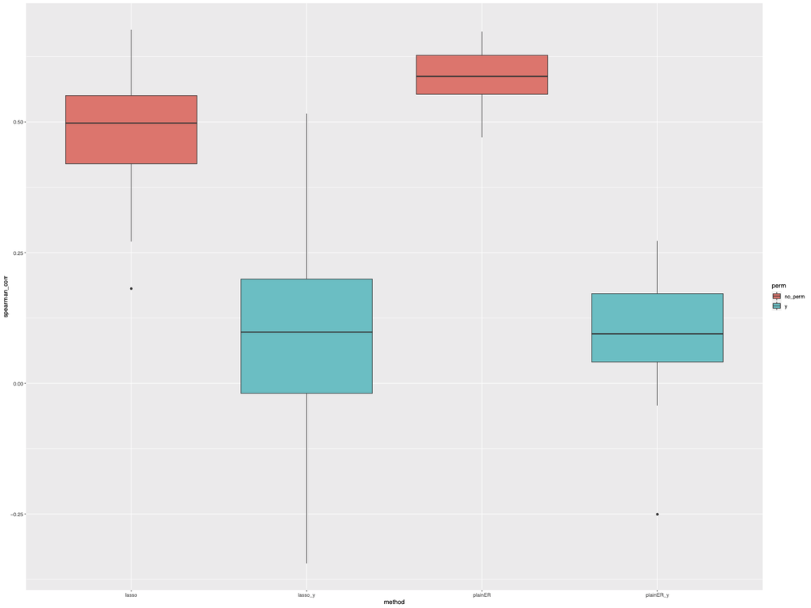

Lambda = 1.0 & 1.5 Boxplots

### Summary

After running both `pipelineER1()` and `pipelineER2()`, we have gained enough information to make an educated estimate of the optimal values to use for $\lambda$ and $\delta$.